# Adjusting Selection Bias

2024-09-08

- Three research questions
  - How do the univariate adjustment methods perform in the context of meta-analysis with multiple, dependent effect sizes?
  - How do the adaptations work for adjusting selection bias in the context of dependent effect sizes?
  - How do the promising adaptations perform versus the comparison methods?

# Compare WILS for different stopping rules

- $\text{k_stop} = 2, 5, 7$.
- Stanley et al. used $\text{k_stop} = 2$ as the stopping rule.
- Hypothesis: the smaller the $\text{k_stop}$, the more biases.
- The smaller k, larger tau, larger mu, smaller weights, more discrepancies.

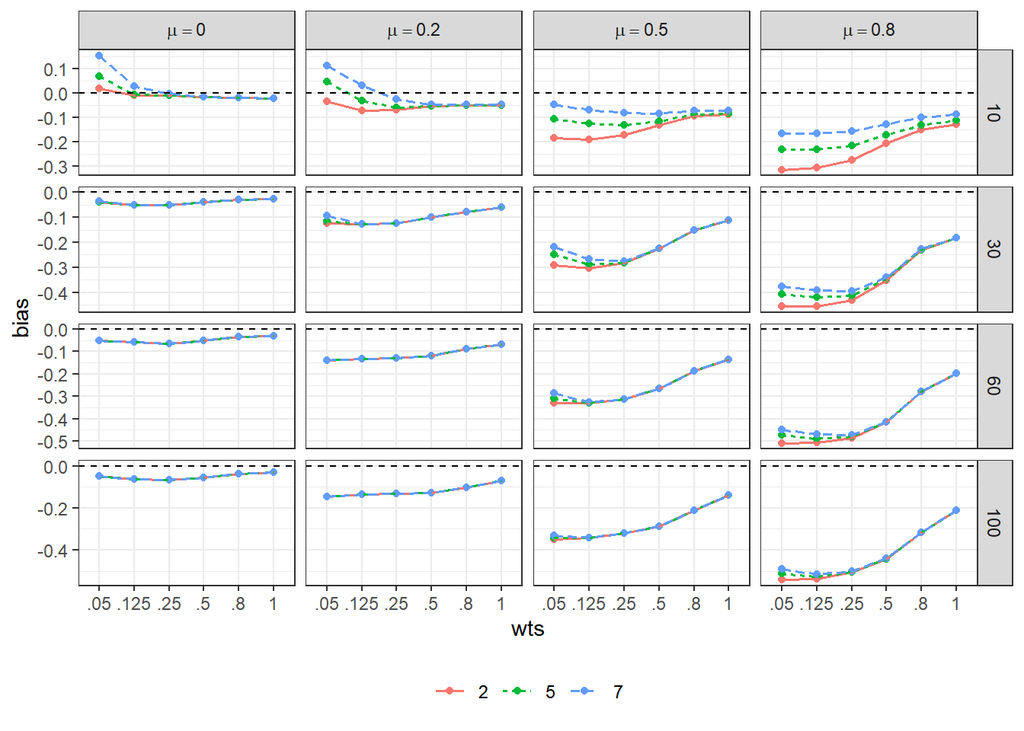

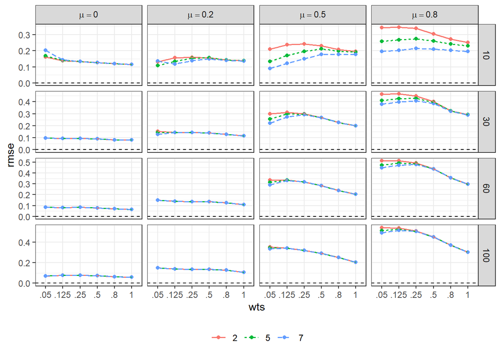

# RQ1: Compare univariate methods

## PET/PEESE

- $k=30$
- Bias
  - PET is less biased than PEESE for $\mu = 0$, especially for large selection.
  - PET tends to under-estimate for $\mu = 0.5$ and $\mu = 0.8$ while PEESE is less under-estimated. However, this is sensitive to between-study heterogeneity.
  - When $\tau = 0.4$, PET seems to be less biased than PEESE. It is also interesting to see that these estimators tend to over-estimate for $\tau = 0.4$.
- RMSE: messy
  - PEESE < PET-PEESE < PET

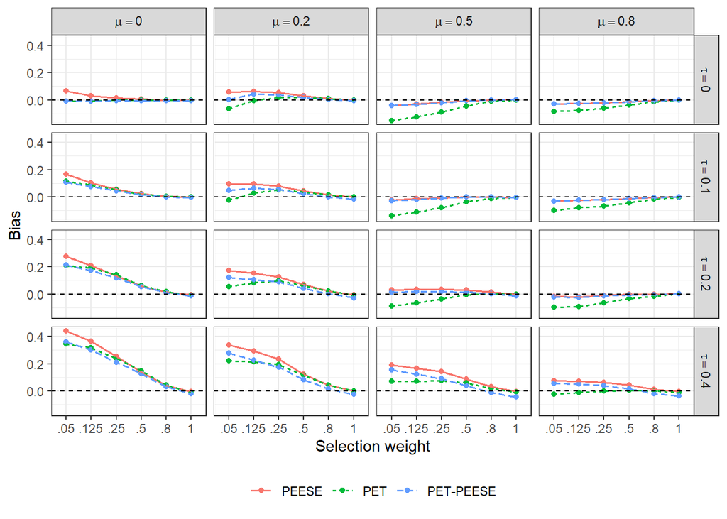

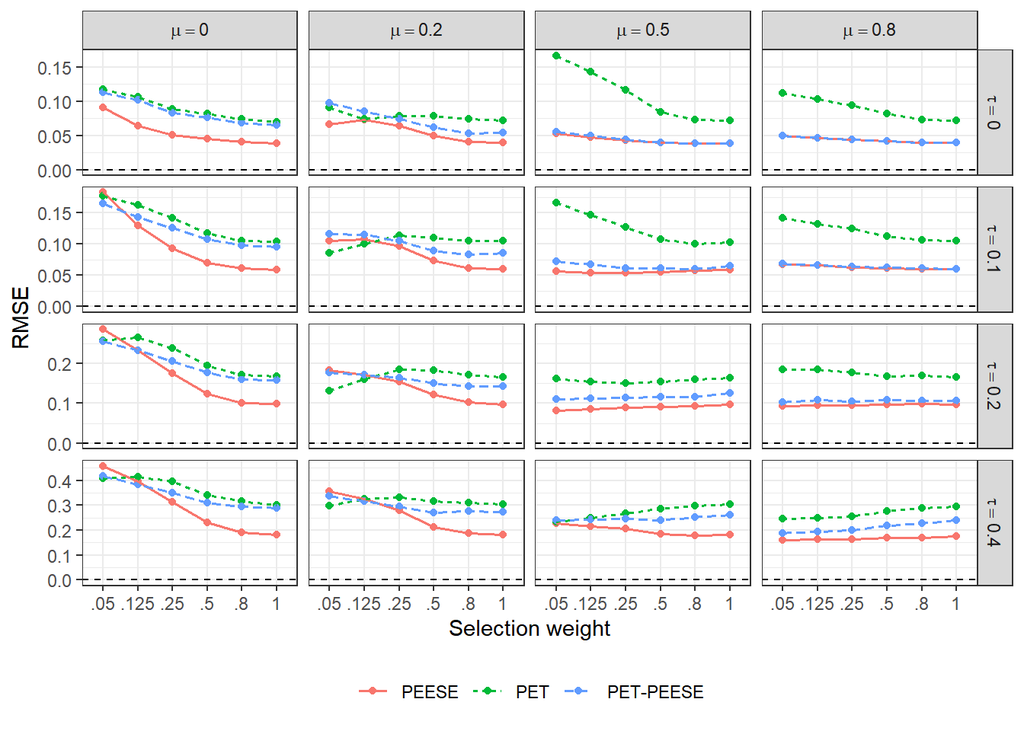

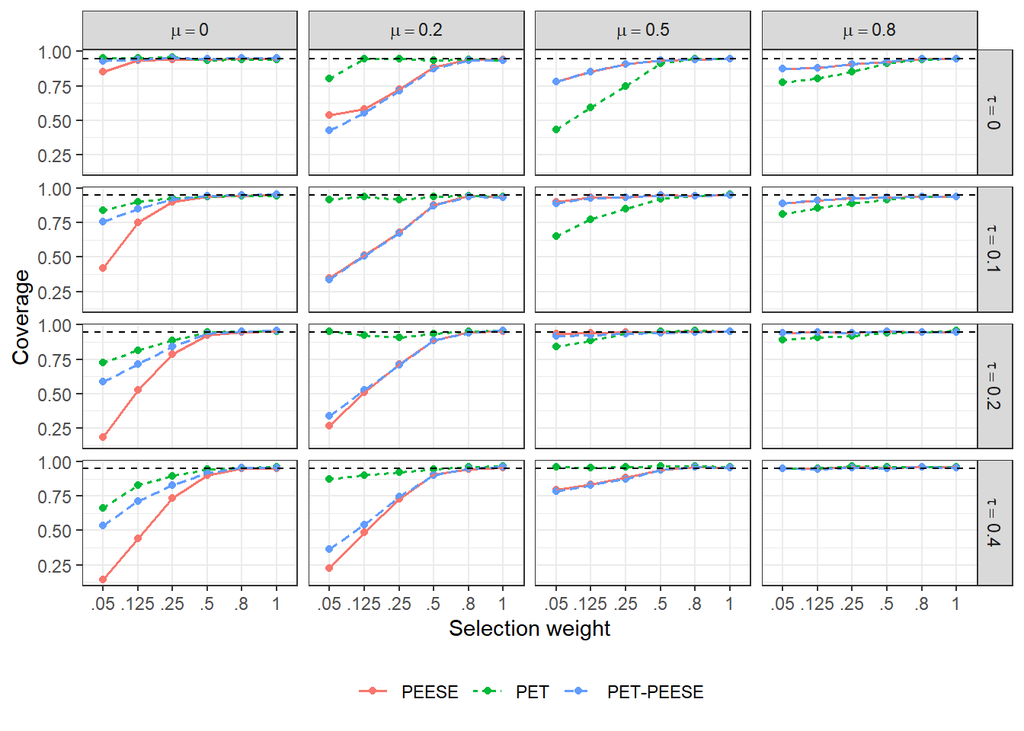

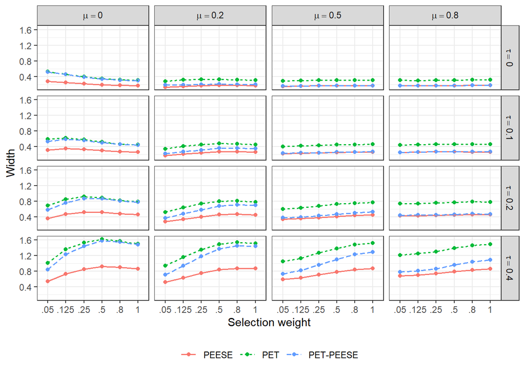

## RQ1: Compare one-step and two-step

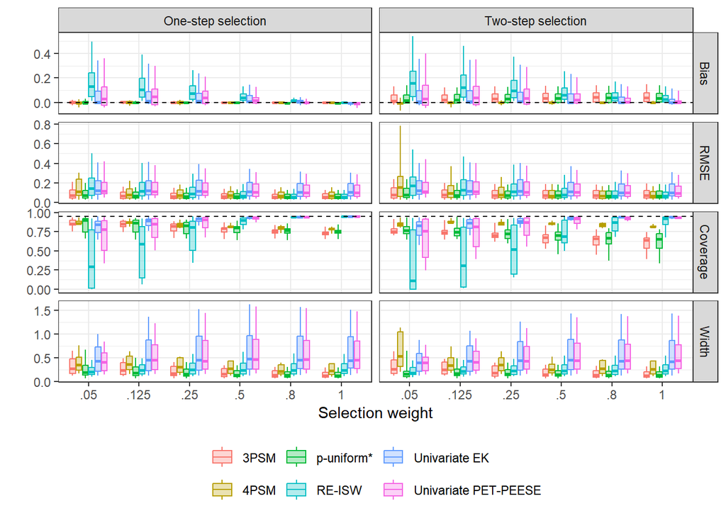

## RQ1: Compare uni methods

- $k=30$
- Did not report p-uniform bc it performs worse than p-unistar.

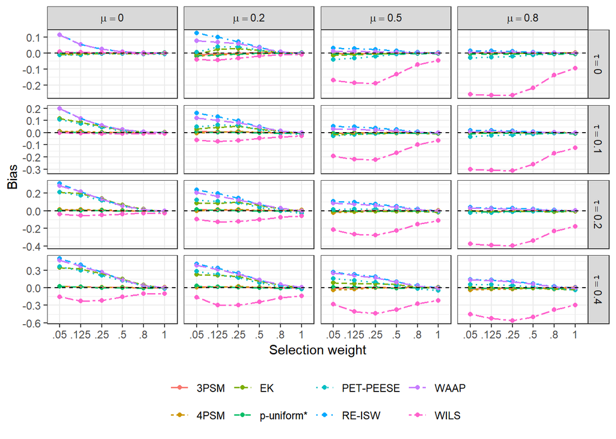

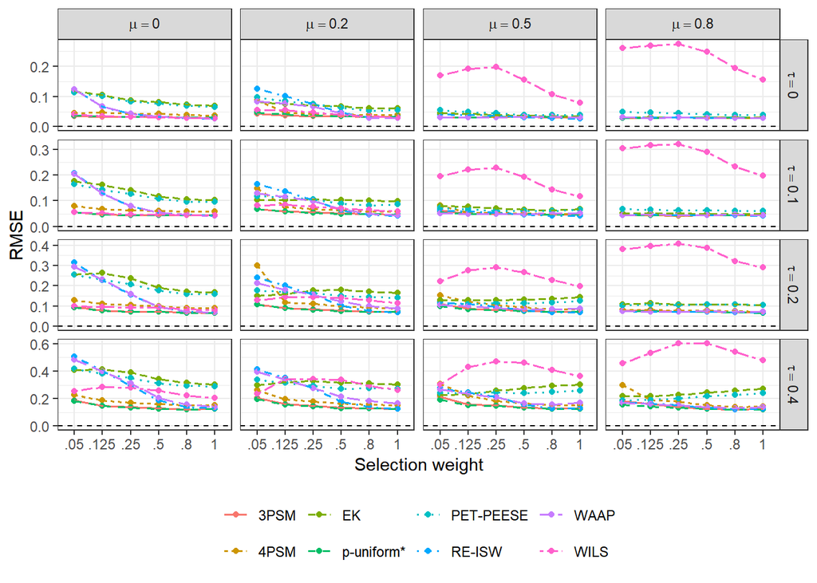

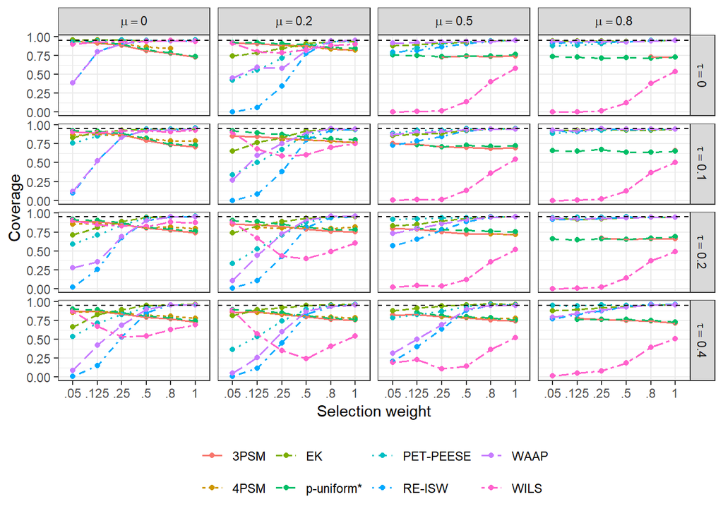

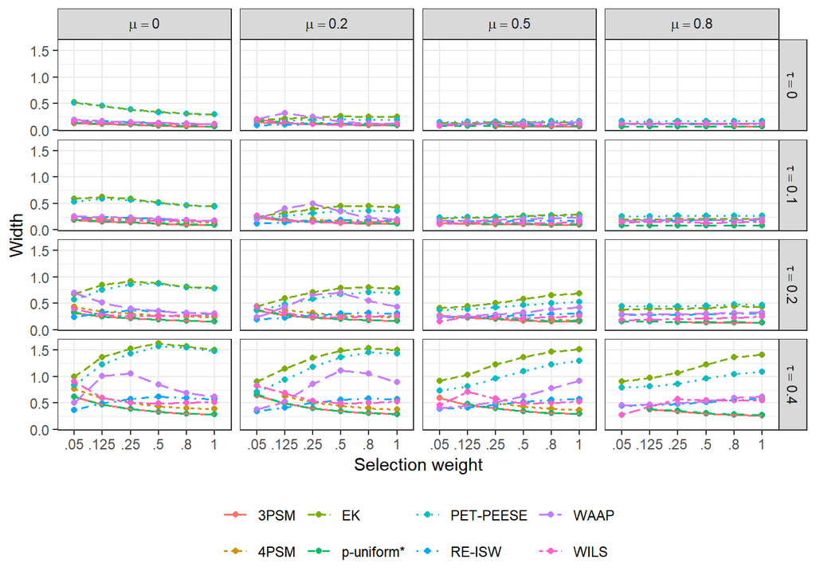

## Replications

### Bom & Rachinger 2019

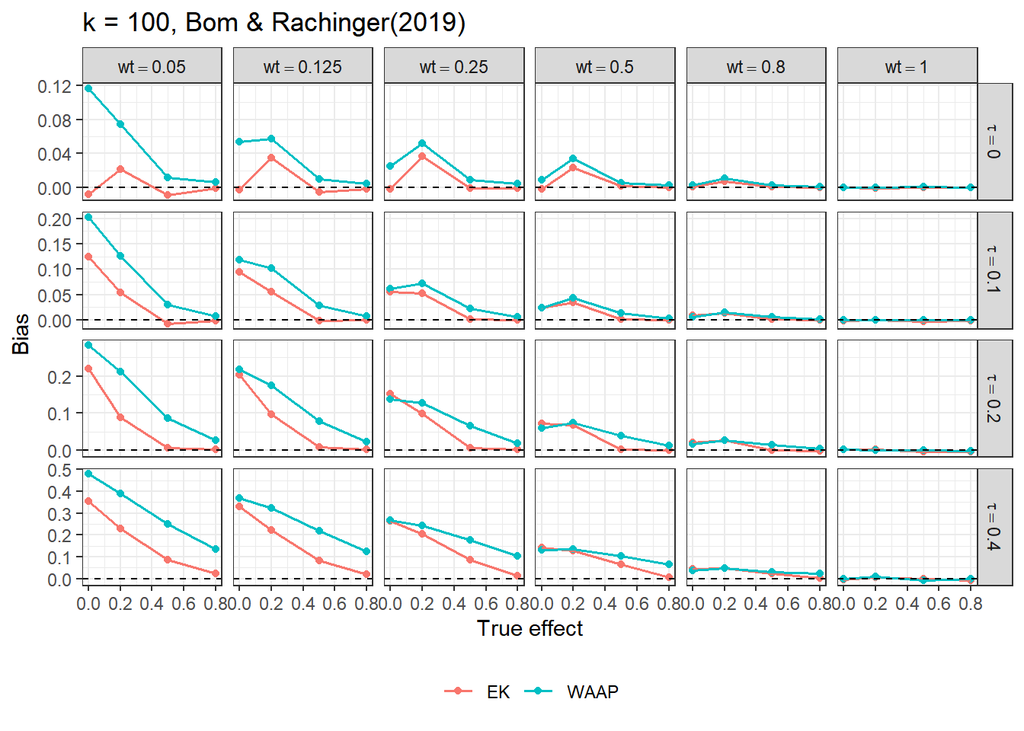

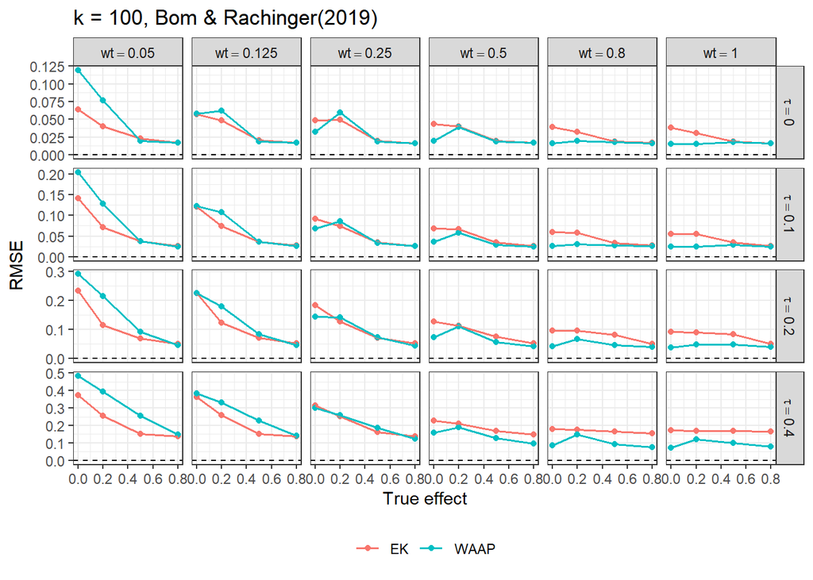

### Stanley & Doucouliagos, 2022

- Figure 1 & 3
  - Not so sure about the discrepancy. Maybe their 50% selection is like our super severe selection. Then the results sort of match.

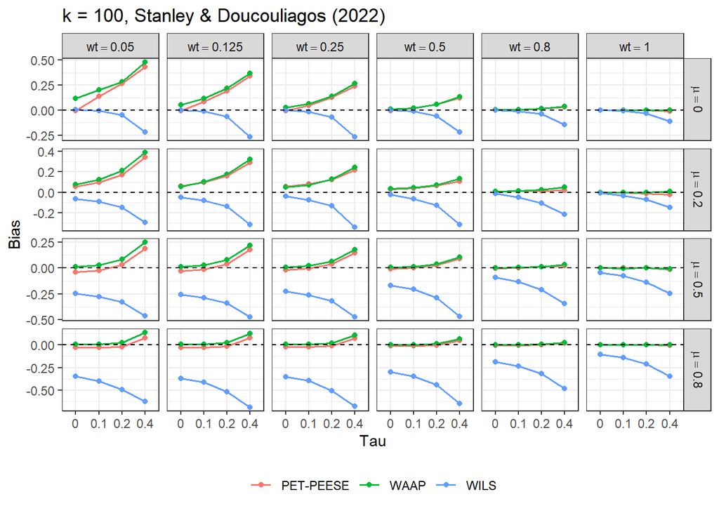

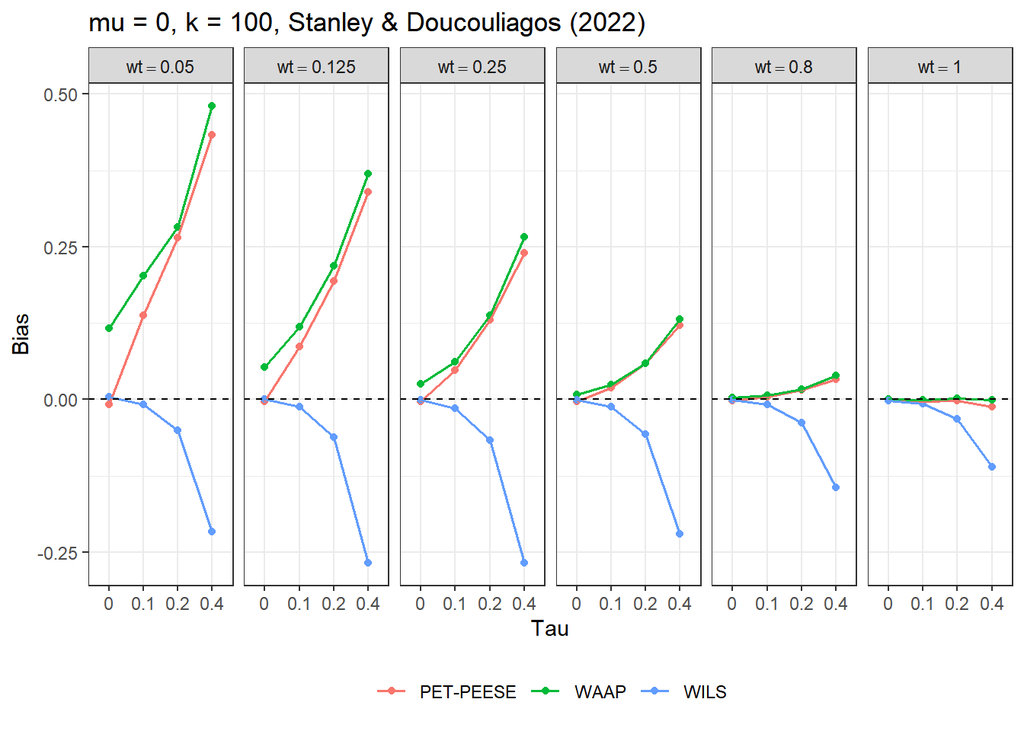

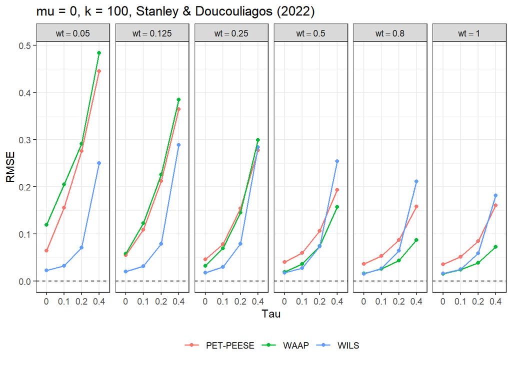

# RQ2: Examine adaptations

## RQ2: Compare adaptations in one-step and two-step

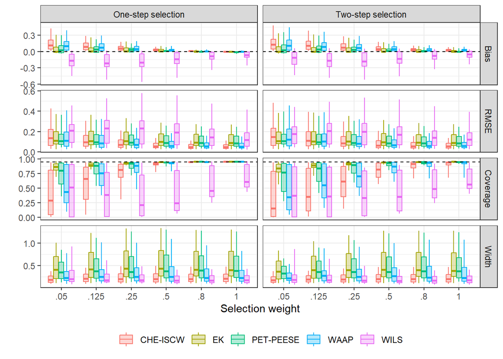

## RQ2: Compare uni and mv reg-based adjustments

### Quantify the differences

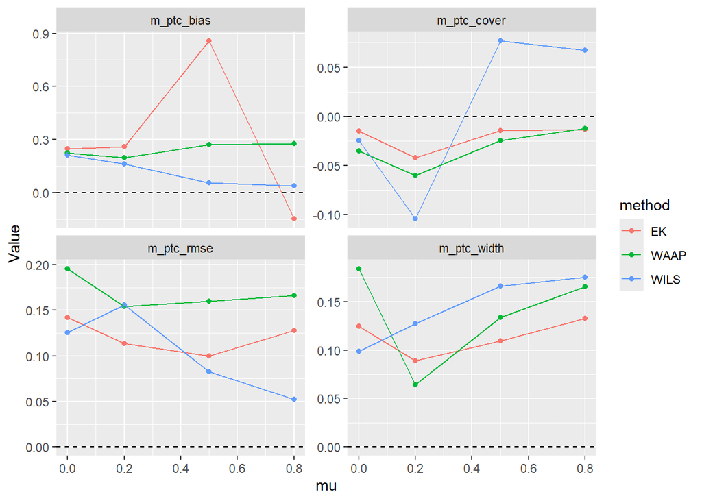

### Graphing the differences

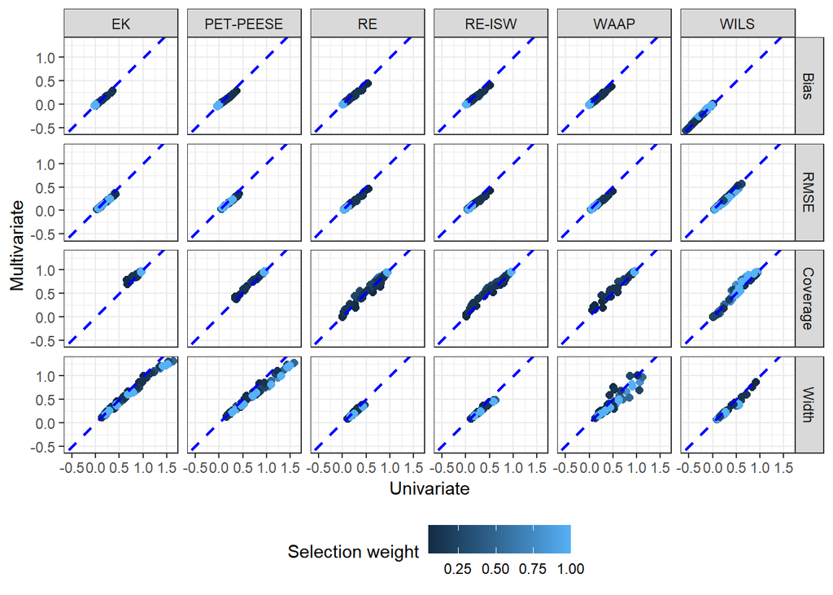

### PET/PEESE

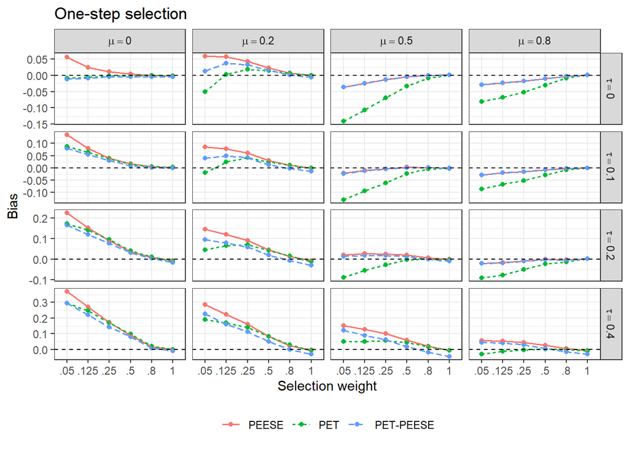

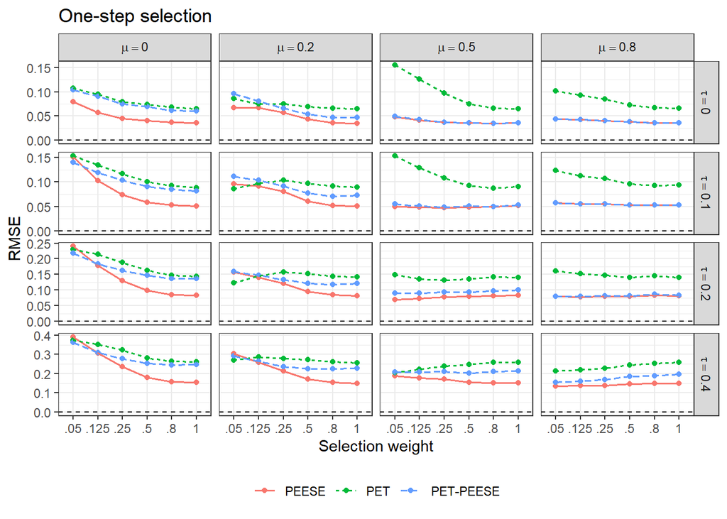

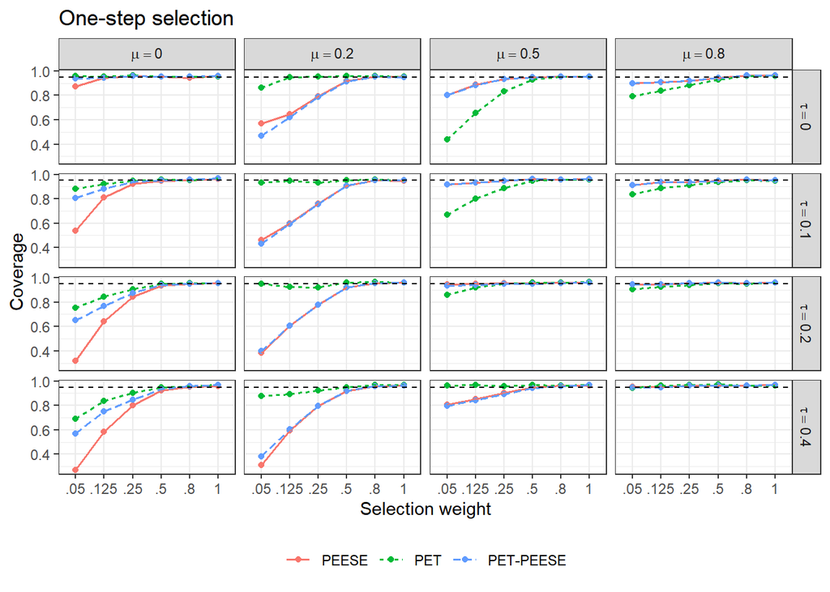

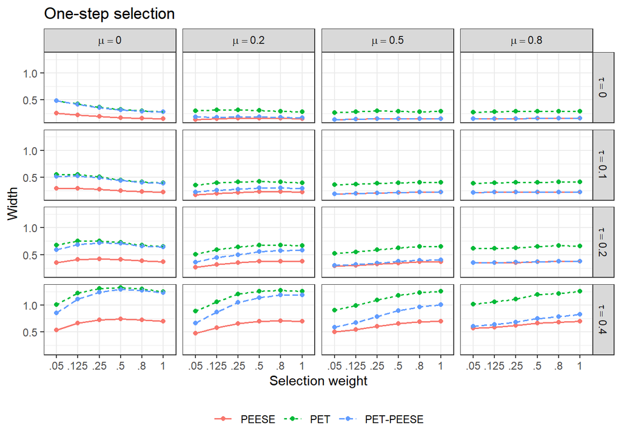

# Compare p-value methods

## Performance

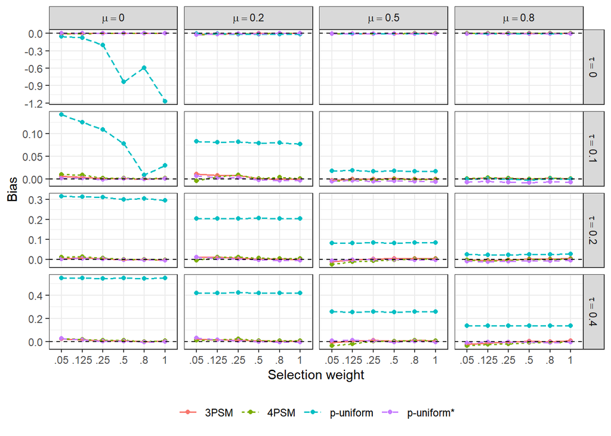

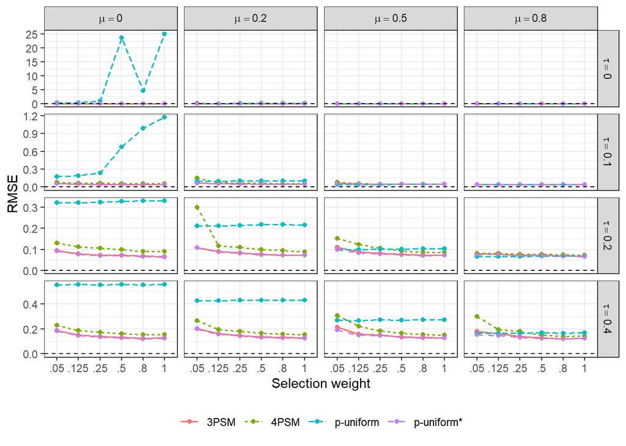

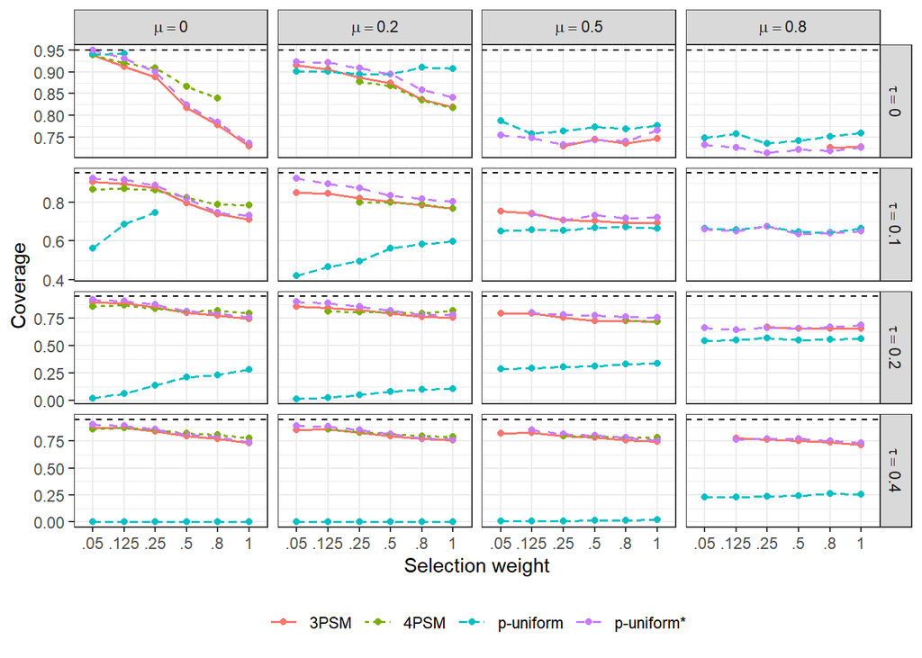

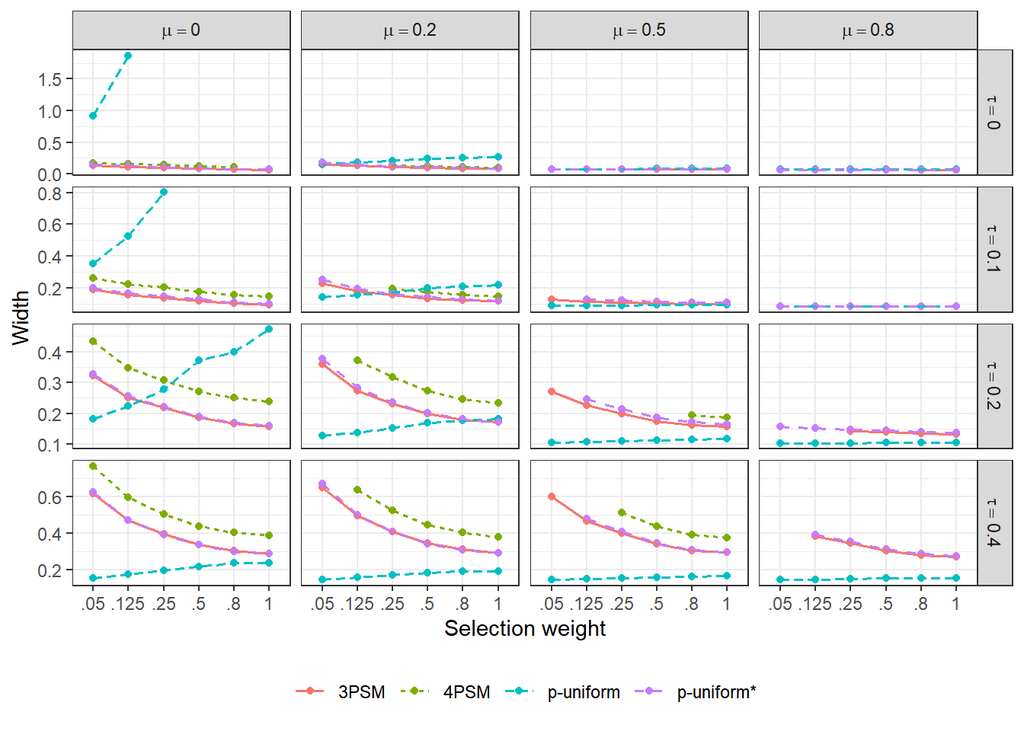

## McShane 2016

- McShane does not have $k=10$ in their simulation.
- Figure 1: $\tau = 0$ & $\lambda = 1$.
  - The CI coverage and width are missing for p-uniform when $k=10$. p-uniform is acting bad for $k=10$.
  - I remove $k=10$ in our study just trying to reproduce McShane’s plots.
  - Summary: could basically reproduce the bias and RMSE results in McShane, where p-uniform has small negative bias and larger RMSE for small true effect compared to 3PSM. However, note that the confidence interval coverage is close to 95% but in our cases the rates are lower, with p-uniform (80%-90% for $\mu=0.2$) having higher coverage rates than 3PSM (75%-85% for $\mu = 0.2$).

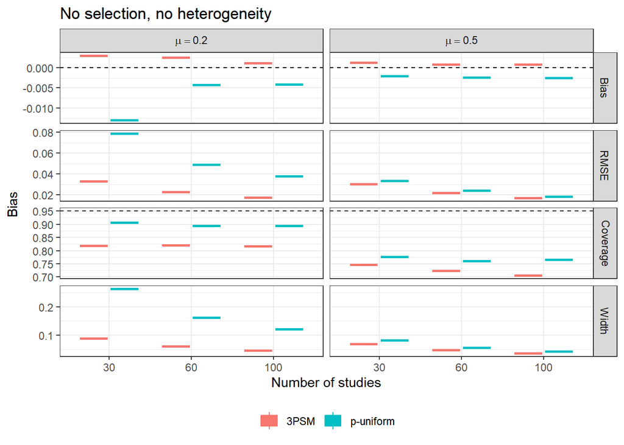

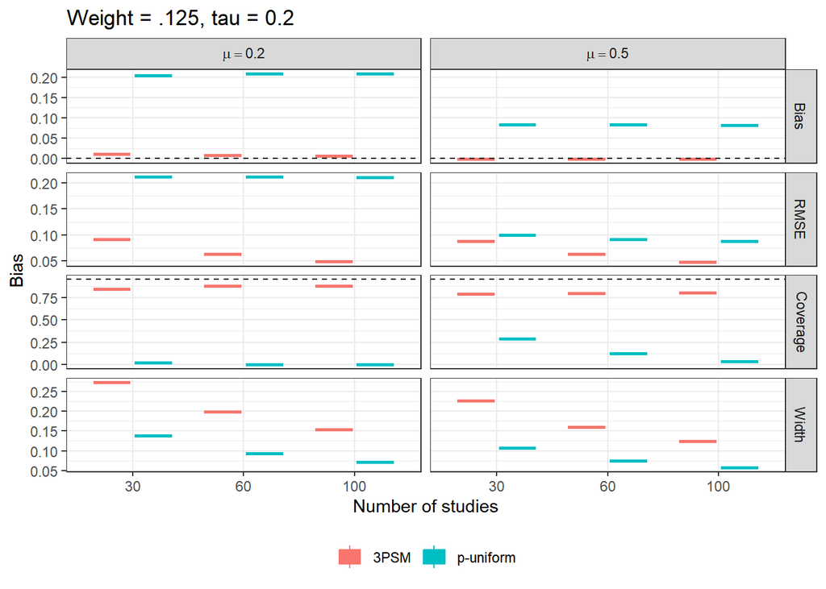

# RQ3: Compare across methods

## RQ3: Compare one- and two-step

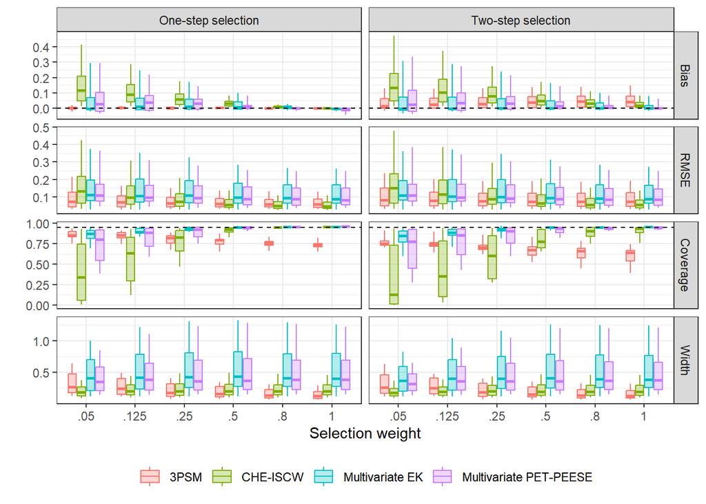